# Particle Filter

### Exercise 4-5 from *Probabilistic Robotics*

This notebook addresses a particle filter (PF) from exercise 4-5 (page 116) in *Probabilistic Robotics* by Thrun, Bergard, and Fox.

- Back to List of PR Notebooks
- [Back to Projects List](http://irwinsnet.github.io)

```python
# Setup notebook for calculations and plotting

# Plotting
# Comment following line (%matplotlib inline) for interactive inline plots
# %matplotlib inline
import matplotlib

# Uncomment following line for interactive inline plots
matplotlib.use('nbAgg')

from mpl_toolkits.mplot3d import axes3d
import matplotlib.pyplot as plt
import matplotlib.patches as mpatches
import matplotlib.cm as cm

# Numerical simulations
import math
import numpy as np
import scipy.stats as stats
import pandas as pd
# import collections

# # Matrix calculations
# import sympy
# from IPython.display import display
# sympy.init_printing(use_latex=True)

# Saving grids to a file
# import pickle

# Debugging
from IPython.core.debugger import set_trace
```

## 1. Exercise 4-5

> 1. Implement Exercise 2 using particle filters instead of histograms, and plot and discuss the results. Investigate the effect of varying numbers of particles on the result.

See notebook 08 for the results of exercise 4-2. Exercise 4-2 is an extension of exercise 3-4 in notebook 06, which uses an extended Kalman filter (EKF).

## Description of Exercise 3-4

#### Movement Model

> We noted in the text that the EKF linearization is an approximation. To see how bad this approximation is, we ask you to work out an example. Suppose we have a mobile robot operating in a planar environment. Its state is its *x-y*-location and its global heading direction $\theta$. Suppose we know $x$ and $y$ with high certainty, but the orientation $\theta$ is unknown. This is reflected by our initial estimate

> $$ \tag{1} \vec \mu = \lgroup \begin{matrix}0 & 0 & 0 \end{matrix} \rgroup $$

> $$ \tag{2} \mathbf{\Sigma} = \left\lgroup \begin{matrix}0.01 & 0 & 0 \cr 0 & 0.01 & 0 \cr 0 & 0 & 10000 \end{matrix} \right\rgroup $$

> For this exercise, we assume the robot moves flawlessly without any noise. Thus, the expected location of the robot after motion will be

> $$ \tag{3} \left\lgroup \begin{matrix} x^\prime \cr y^\prime \cr \theta^\prime \end{matrix} \right\rgroup = \left\lgroup \begin{matrix} x + \cos \theta \cr y + \sin \theta \cr \theta \end{matrix} \right\rgroup $$

#### Measurement Model

> Our measurement shall be a noisy projection of the x-coordinate of the robot, with covariance $Q = 0.01$. Specify the measurement model. Now apply the measurement both to your intuitive posterior, and formally to the EKF estimate using the standard EKF machinery. Give the exact result of the EKF, and compare it with the result of your intuitive analysis.

## Particle Filter Overview

1. **Particle Filter Algorithm ($X_{t-1}, u_t, z_t$):**
2. $\quad \overline{X_t} = X_t = \emptyset$
3. $\quad$for $m = 1$ to $M$ do
4. $\qquad$sample $x_t^{[m]} \sim p(x_t \mid u_t, x_{t-1}^{[m]})$
5. $\qquad w_t^{[m]} = p(z_t \mid x_t^{[m]})$
6. $\qquad \overline X_t = \overline X_t + \langle x_t^{[m]}, w_t^{[m]}\rangle$
7. $\quad$endfor
8. $\quad$for $m = 1$ to $M$ do
9. $\qquad$draw $i$ with probability $\propto w_t^{[i]}$
10. $\qquad$add $x_t^{[i]}$ to $X_i$
11. $\quad$endfor
12. $\quad$return $X_t$

## Particle Set

```python
M = 1000 # Number of particles
```

The class PSet uses a numpy structured array to represent a particle set. It also contains array columns for weights and an empirical cumulative distribution function that will be used for the measurement update portion of the PF algorithm.

```python
class PSet(object):

    def __init__(self, num_particles):
        """Initializes a PSet object with all particles set to (0, 0)"""
        self.num_particles = num_particles
        self.ptcs = np.zeros(num_particles,
                                   dtype=[("x", np.float16),
                                          ("y", np.float16),
                                          ("theta", np.float16),
                                          ("weights", np.float32),
                                          ("cdf", np.float32)])
        self.belief = False
        self.measurement = None
        self.posterior = False


    def __getitem__(self, key):
        return self.ptcs[key]


    def __setitem__(self, key, value):
        self.ptcs[key] = value


    @property
    def shape(self):
        return self.ptcs.shape


    def set_cdf(self):
        """Populates the 'cdf' column, based on particle weights.
        """
        weight_sum = 0
        for row in self.ptcs:
            weight_sum = row["weights"] + weight_sum
            row["cdf"] = weight_sum


    def resample(self):
        """Returns new Posterior PSet resulting from PF resampling step
        """
        sum_weights = np.sum(self["weights"])
        rand_samples = np.sort(np.random.random_sample(size=self.num_particles)
                               * sum_weights)

        num_ptcl = self.num_particles
        posterior = PSet(num_ptcl)

        post_idx = 0
        bel_idx = 0

        while bel_idx < num_ptcl:
            while ((post_idx < num_ptcl and bel_idx < num_ptcl) and
                   rand_samples[post_idx] < self["cdf"][bel_idx]):
                posterior.ptcs["x"][post_idx] = self["x"][bel_idx]
                posterior.ptcs["y"][post_idx] = self["y"][bel_idx]
                posterior.ptcs["theta"][post_idx] = self["theta"][bel_idx]
                post_idx = post_idx + 1
            bel_idx = bel_idx + 1
        posterior.posterior = True
        posterior.belief = False
        return posterior

    def clear_weights(self):
        """Sets weights and CDF to zero."""
        self.ptcs["weights"] = 0
        self.ptcs["cdf"] = 0

    def covariance(self):
        """Calculates the coviance matrix of the particle set."""
        cov_array = np.array([self.ptcs["x"], self.ptcs["y"],
                              self.ptcs["theta"]])
        return np.cov(cov_array)

    def mean(self):
        """Returns the means for the particle set"""
        return (np.mean(self["x"]), np.mean(self["y"]), np.mean(self["theta"]))

    def theta_x(self):
        return np.cos(self["theta"])

    def theta_y(self):
        return np.sin(self["theta"])

    def scatter_plot(self, title, lims=None):
        fig = plt.figure()
        plt.plot(self["x"], self["y"], 'b.')
        plt.title(title)
        plt.xlabel("x")
        plt.ylabel("y")
        if lims is not None:
            plt.xlim(lims[0])
            plt.ylim(lims[1])
        plt.grid()
        plt.show()
        plt.close()
```

### Particle Set at Time 0

At time $t = 0$ we know the x and y position of the robot precisely, but the heading $\theta$ is unknown.

```python
pset0 = PSet(M)
pset0["theta"] = np.random.random_sample(M) * 2 * math.pi
```

## State Transition

The state transition portion of the generic Bayes filter algorithm is addressed by lines 3 and 4 in the particle filter algorithm. We will use equation (3) for this update, as implemented in the `next_step` function.

```python
def next_step(pset):
    """Applies a state transition to creates a new particle set for time t + 1.
    """
    num_particles = pset.num_particles
    pset_next = PSet(num_particles)
    pset_next["x"] = pset["x"] + np.cos(pset["theta"])
    pset_next["y"] = pset["y"] + np.sin(pset["theta"])
    pset_next["theta"] = pset["theta"]
    pset_next.belief = True
    return pset_next
```

### Time $t = 1$

```python
pset1 = next_step(pset0)
```

```python
pset1.mean()
```

```
(-0.01403, -0.0266, 3.146)
```

```python
pset1.covariance()
```

```
array([[ 0.50749185,  0.01183272, -0.04606508],
       [ 0.01183272,  0.49259936, -0.98671339],
       [-0.04606508, -0.98671339,  3.24723679]])
```

```python
def plot_grid(pset, title, xlim=(-1.2, 1.2), ylim=(-1.2, 1.2)):
    fig2 = plt.figure()
    plt.quiver(pset["x"], pset["y"], pset.theta_x(), pset.theta_y(), scale=40)
    plt.xlabel("x position")
    plt.ylabel("y position")
    plt.xlim(xlim)
    plt.ylim(ylim)
    plt.grid()
    plt.title(title)
    plt.show()
    plt.close()
```

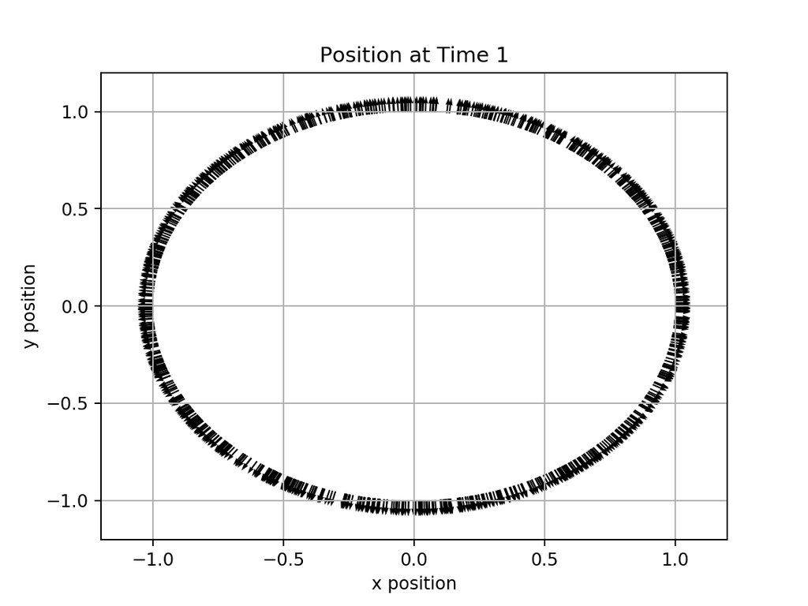

```python
plot_grid(pset1, "Position at Time 1")
```

## Measurement Update

```python
MEASUREMENT_VARIANCE = 0.01

def weight(x_coord, meas, var):
    return stats.norm.pdf(meas, loc=x_coord, scale=math.sqrt(var))

weights = np.vectorize(weight, excluded=["meas", "var"], otypes=[np.float16])
```

Now we have to:

1. Assign the weights to the *weights* column of the structured array contained within our *PSet* object.
2. Create an empirical cumulative distribution function (CDF) based on the particle weights.

```python
pset1["weights"] = weights(pset1["x"], 1,
                           MEASUREMENT_VARIANCE)  # Assign weights
pset1.set_cdf()  # Create empirical CDF from weights.
pset1.measurement = 1
```

Let's take a look at the first few lines of the particle set:

```python
pset1[0:10]
```

```
array([( 0.1869,  0.9824, 1.383 , 0.       , 0.       ),
       ( 0.0805, -0.9966, 4.793 , 0.       , 0.       ),
       ( 0.9326, -0.3608, 5.914 , 3.1796875, 3.1796875),
       (-0.821 , -0.572 , 3.75  , 0.       , 3.1796875),
       (-0.951 , -0.3083, 3.455 , 0.       , 3.1796875),
       (-0.807 , -0.591 , 3.773 , 0.       , 3.1796875),
       (-0.9795, -0.2008, 3.344 , 0.       , 3.1796875),
       (-0.1145, -0.9937, 4.598 , 0.       , 3.1796875),
       ( 0.94  ,  0.3413, 0.3484, 3.3320312, 6.5117188),
       ( 0.1387, -0.99  , 4.85  , 0.       , 6.5117188)],
      dtype=[('x', '<f2'), ('y', '<f2'), ('theta', '<f2'), ('weights', '<f4'), ('cdf', '<f4')])
```

Finally, we'll complete lines 8 through 11 of the PF algorithm via the `PSet.resample()` method.

```python
post1_m1 = pset1.resample()
```

Here are the results:

```python
post1_m1.mean()
```

```
(0.952, 0.0169, 3.002)
```

```python
post1_m1.covariance()
```

```
array([[ 2.79061656e-03,  2.42920150e-04, -2.00202317e-04],
       [ 2.42920150e-04,  9.02974351e-02, -7.04827228e-01],
       [-2.00202317e-04, -7.04827228e-01,  8.31050648e+00]])
```

```python
pset1.clear_weights()
pset1["weights"] = weights(pset1["x"], -1,
                           MEASUREMENT_VARIANCE)  # Assign weights
pset1.set_cdf()  # Create empirical CDF from weights.
pset1.measurement = -1
```

```python
post1_mneg1=pset1.resample()
```

```python
post1_mneg1.mean()
```

```
(-0.9517, -0.01302, 3.156)
```

```python
post1_mneg1.covariance()
```

```
array([[ 0.00250957, -0.00152575,  0.00159878],
       [-0.00152575,  0.09204738, -0.09523462],
       [ 0.00159878, -0.09523462,  0.09858042]])
```

Much better.

## Visualization

Measurement at $x = -1$.

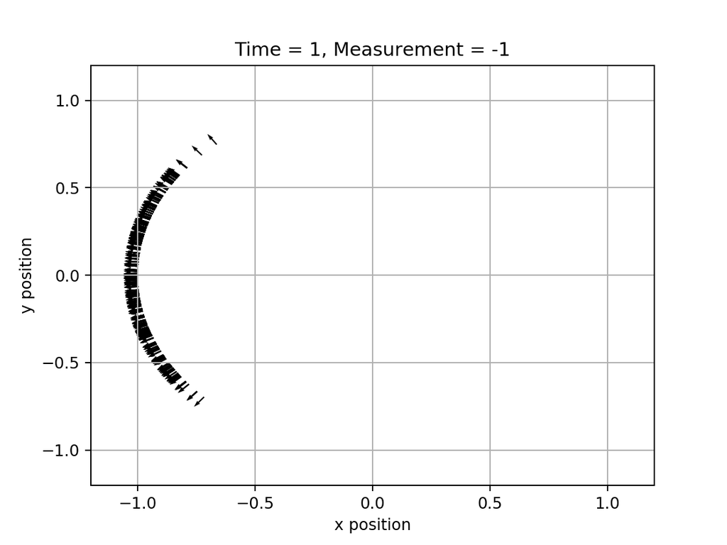

```python
plot_grid(post1_mneg1, "Time = 1, Measurement = -1")
```

Let's try $x = 0$

```python
pset1.clear_weights()
pset1["weights"] = weights(pset1["x"], 0,
                           MEASUREMENT_VARIANCE)  # Assign weights
pset1.set_cdf()  # Create empirical CDF from weights.
pset1.measurement = 0
```

```python
post1_0=pset1.resample()
```

```python
post1_0.mean()
```

```
(-0.005116, -0.1252, 3.34)
```

```python
post1_0.covariance()
```

```
array([[ 1.04733602e-02, -1.37264113e-03,  3.75375856e-03],
       [-1.37264113e-03,  9.74882915e-01, -1.53414780e+00],
       [ 3.75375856e-03, -1.53414780e+00,  2.42484349e+00]])
```

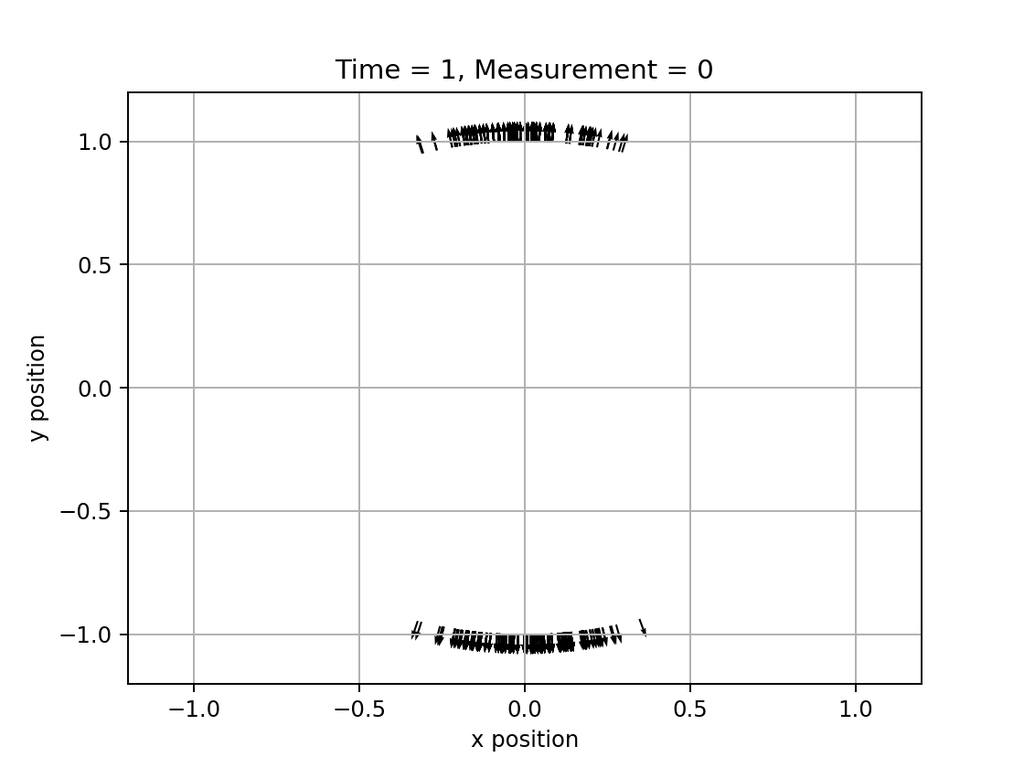

```python
plot_grid(post1_0, "Time = 1, Measurement = 0")
```

The measurement of $x = 0$ results in a bimodal belief, which the particle filter is able to represent. Note that the variance for $x$ is low compared to the variance for $y$. Also, the mean is not a good estimate of the position, in the sense that the robot is not at the mean state. Finally, note that the mean $\theta$ is approximately $\pi$ (pointing to the left).

- Back to Top
- Back to List of PR Notebooks
- [Back to Projects List](http://irwinsnet.github.io)

*Stacy Irwin, August 25 2018*